# Assignment 1

An Introduction to Data Visualizaiton (DS4073)

2023/04/14

### Important Dates:

**Due date: 2023-04-28**

*Tip*: You may need the option (eval = FALSE) for r code in R markdown — to not run the code.

### Description

Please complete the codes such that they can produce the same consequent result. Replace the keyword `REPLACE` with suitable code in the text. Submit the `.html` and `.rmd` files to iSpace.

#### Q1. (10 marks) List and data frame

1. (5 marks) Construct a list that contains 4 components named Zhuhai, Wuhan, Shanghai, Beijing. Each component is a 3-dimensional vector contains weather, highest temperature, lowest temperature, which are given in the output.

```r
# Construct a list
Zhuhai <- REPLACE
Wuhan <- REPLACE
Shanghai <- REPLACE
Beijing <- REPLACE
weather <- list(REPLACE)
print(weather)
```

```
## $Zhuhai
## [1] "Mostly Sunny" "29"           "14"
##
## $Wuhan
## [1] "Mostly Sunny" "30"           "19"
##
## $Shanghai
## [1] "Cloudy" "26"     "12"
##
## $Beijing
## [1] "Rainy" "19"    "10"
```

2. (5 marks) Construct a data frame with 4 rows and 4 columns like the output.

```r
weather <- data.frame(REPLACE)
print(weather)
```

```
##       city weather high_Tem low_Tem
## 1   Zhuhai   Sunny       20      14
## 2    Wuhan   Sunny       21      19
## 3 Shanghai  Cloudy       16      12
## 4  Beijing   Rainy       19      15
```

#### Q2. (20 marks) Read file and data processing

1. (10 marks) Selecting variables and observations  
   Please download the data file `fuel_economy.csv` from the iSpace first. Use the function `select` in the package `dplyr` to deal with the fuel economy data.

*Hint*: Options `warning=FALSE`, `message=FALSE` for not displaying the warning messages.

```r
# Loading package
library(dplyr)

# Read fuel economy data from the file named 'fuel_economy.csv' and
# assign it to the variable 'fuel_eco'
fuel_eco <- REPLACE

# Select the variables manufacturer, model, year, and fl
newdata <- REPLACE

# Print the variable names
print(colnames(newdata))
```

```
## [1] "manufacturer" "model"        "year"         "fl"
```

```r
# Select all the variables except cty and hwy
newdata <- REPLACE

# Print the variable names
print(colnames(newdata))
```

```
##  [1] "X"            "manufacturer" "model"        "displ"        "year"
##  [6] "cyl"          "trans"        "drv"          "fl"           "class"
```

```r
# Select the models that are suv classes and contain 4 cylinders (variable: cyl)
newdata <- REPLACE

# Print the selected models
print(newdata)
```

```
##     X manufacturer        model displ year cyl      trans drv cty hwy fl class
## 1 160       subaru forester awd   2.5 1999   4 manual(m5)   4  18  25  r   suv
## 2 161       subaru forester awd   2.5 1999   4   auto(l4)   4  18  24  r   suv
## 3 162       subaru forester awd   2.5 2008   4 manual(m5)   4  20  27  r   suv
## 4 163       subaru forester awd   2.5 2008   4 manual(m5)   4  19  25  p   suv
## 5 164       subaru forester awd   2.5 2008   4   auto(l4)   4  20  26  r   suv
## 6 165       subaru forester awd   2.5 2008   4   auto(l4)   4  18  23  p   suv
## 7 174       toyota  4runner 4wd   2.7 1999   4 manual(m5)   4  15  20  r   suv
## 8 175       toyota  4runner 4wd   2.7 1999   4   auto(l4)   4  16  20  r   suv
```

2. (10 marks) Grouping and summarizing data

```r
# Calculate the mean displacement (variable: displ) and mean highway miles per gallon (variable: hwy)
newdata <- REPLACE
newdata
```

```
##   mean_displ mean_hwy
## 1   3.471795 23.44017
```

```r
# Calculate the mean of displ and hwy for 8 cylinders models by manufacture
newdata <- REPLACE
newdata
```

```
## # A tibble: 11 × 3
##    manufacturer mean_displ mean_hwy
##    <chr>             <dbl>    <dbl>
##  1 audi               4.2      23
##  2 chevrolet          5.8      19.9
##  3 dodge              5.03     15.7
##  4 ford               4.89     18.5
##  5 jeep               5.18     16
##  6 land rover         4.3      16.5
##  7 lincoln            5.4      17
##  8 mercury            4.8      18
##  9 nissan             5.6      18
## 10 pontiac            5.3      25
## 11 toyota             5.03     16.7
```

#### Q3 (20 marks) Visualization with `ggplot2`

The data **“LifeSavings.csv”** contanis the information on the average life cycle savings of 50 countries over decade 1960-1970. The descriptions of 6 variables are listed below.

| Variable | Description |
| --- | --- |
| country | 50 countries |
| sr | aggregate personal savings |
| pop15 | percentage of population under 15 |
| pop75 | percentage of population over 75 |
| dpi | real per-capita disposable income |
| ddpi | percentage growth rate of dpi |

1. (10 marks) Please use the ggplot to draw the bar chart for two variables *country* and *sr*. The theme `theme_classic()` may be needed.

```r
# write your code here
```

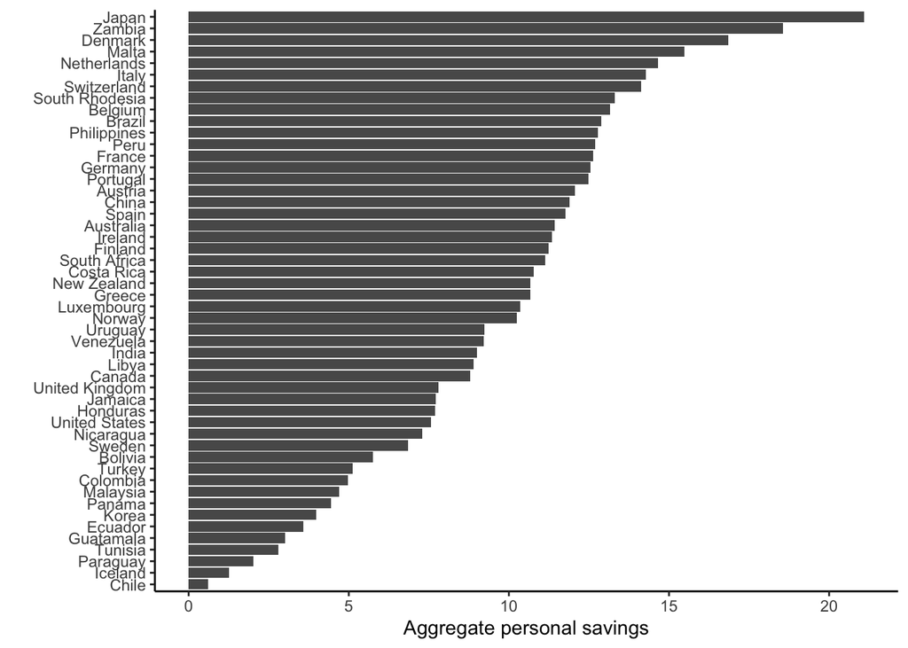

2. (10 marks) Please highlight the countries that the percentage of population less than 15 years old (pop15) is greater than 40 and percentage of population over 75 years old (pop75) is less than 1. You may need the colors set {“lightgray”, “#F1A340”}.

```r
# write your code here
```

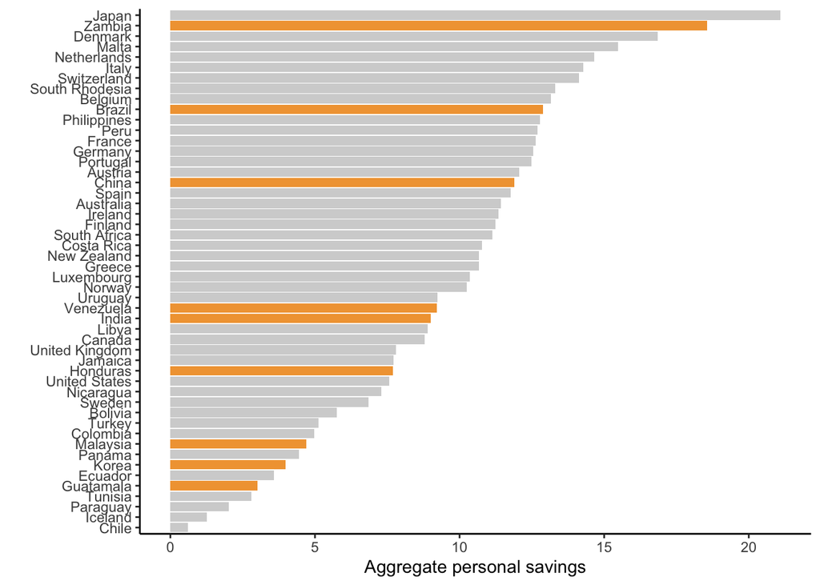

#### Q4 (50 marks) A tiny project

The data file **Real-Estate.txt** contains information on the homes sold in the Denver area during the year 2003. The variables in this data file are as follows:

| Variable | Description |
| --- | --- |
| Price | Selling price in $1000 |
| Bedrooms | Number of bedrooms |
| Size | Size of the home in square feet |
| Pool | Whether having a swimming Pool (yes or no) |
| Distance | Distance from the home to the center of the city |
| Township | Township No. |
| Garage | Whether is garage attached (yes or no) |
| Baths | Number of bathrooms |

1. (10 marks) Please analyze the data and abstract at least 2 tasks.
2. (20 marks) Design your visualization according to the design principles and give your justification. Please write your design thoughts clearly.
3. (20 marks) Implement your visualization by **R**. Please write the annotations for each step.

```r
# write your code here
```